# ML Bayesian Linear Regression and Logistic Regression web

### **Optimization, Linear regression, Bayesian linear regression and Logistic regression**

Ron Maor

```python
import jax
import jax.numpy as jnp
import numpy as np
from jax import random, jit, vmap, grad, value_and_grad, jacfwd , hessian
from jax.scipy.stats import multivariate_normal
from jax.tree_util import tree_multimap
import matplotlib.pyplot as plt
from IPython.display import clear_output
plt.style.use('ggplot')
```

## Maximum A Posteriori Probability (MAP)

Consider the problem of MAP estimation for the mean $μ$ of a Gaussian distribution with a known standard deviation $σ$ . For the prior distribution, assume a Gaussian with mean $0$ and standard deviation $γ$.

1. Determine the function that we need to maximize. You do not need to determine the constant terms explicitly.

##### *Answer* ***(1)***

Assuming the prior is: $ \mu \sim \mathcal{N}(0,\gamma)$ and the data sequence of $X$ is $X \sim \mathcal{N}(\mu,\sigma) $, we can use Bayes rule to know that the psoterior distribution is the product of the above two. The MAP estimation will be the parameter $\mu$ which will maximize the following:

$$ \text{argmax}_\mu \left[ \frac{1}{\sqrt{2\pi\gamma^2}}e^{-\frac{1}{2}\left( \frac{\mu}{\gamma}\right)^2} \prod_{i=1}^{N}\frac{1}{\sqrt{2\pi\sigma^2}}e^{-\frac{1}{2}\left( \frac{x_i-\mu}{\sigma}\right)^2} \right] $$

2. Determine the optimal value of $μ$ by setting the derivative to $0$

##### *Answer* ***(2)***

Continuing expanding the expression above we get (since we are just trying to find the argument that maximizes the function):

$$ \text{argmax}_\mu \left [\left( \frac{\mu}{\gamma} \right)^2 + \sum_{i=1}^{N} \left(\frac{x_i-\mu}{\sigma}\right)^2 \right]$$

Taking the derivative of the above expression we get:

$$ \frac{\partial}{\partial\mu} \left [\left( \frac{\mu}{\gamma} \right)^2 + \sum_{i=1}^{N} \left(\frac{x_i-\mu}{\sigma}\right)^2 \right] = \frac{2\mu}{\gamma^2} + \frac{2\sum x_i - 2\mu N}{\sigma^2} $$

Setting the above expression to zero and solving for $\mu$ we get:

$$ \mu_\text{MAP} = \frac{\frac{1}{\sigma^2}}{\frac{1}{\gamma^2} + \frac{N}{\sigma^2}} \sum x_i $$

## Bayesian Linear Regression

Consider a Bayesian linear regression model where the outputs $y$ are distributed according to a Gaussian likelihood $p ( y | x , α , β , γ )$ corresponding to a linear model $y = α x + β + ϵ$. Here $γ$ represents the noise level in the observed data, i.e. it corresponds to the precision of the data likelihood. In this case, the likelihood can be further expressed as:

$$ p(y\lvert x, \alpha, \beta, \gamma) = (\frac{\gamma}{\sqrt{2\pi}})^n\exp(-\frac{\gamma(\sum_{i=1}^n\|y_i - x_i\alpha - \beta\|^2_2)}{2}) $$

In a Bayesian setting we would like to assume prior distributions on the unknown parameters $α$ , $β$ and $γ$ . Here we assume $p ( α ) = \mathcal{N}( 0 , 1 ) \ \, p ( β ) = \mathcal{N}( 0 , 1 )$ and $p ( γ ) = \Gamma(2, 1)$ is a Gamma distribution.

> Please write down the posterior conditional distribution for each of those parameters, i.e. : $$ p(α|x,y,β,γ)$$$$ p(β|x,y,α,γ)$$$$ p(γ|x,y,α,β)$$

> Comment on your results

##### *Answer*

According to Bayes, we know that: $$ \text{posterior} \propto \text{likelihood} \ \cdot \ \text{prior} $$

It's also given that: $$ p(\alpha)= \frac{1}{\sqrt{2\pi}}e^{-\alpha^2/2} \\ p(\beta)= \frac{1}{\sqrt{2\pi}}e^{-\beta^2/2} \\ p(\gamma)= \frac{\gamma e^{-\gamma}}{2} $$

So we get:

$$ p(\beta|x,y,\alpha,\gamma) = \left(\frac{\gamma}{\sqrt{2\pi}}\right)^ne^{-\frac{\gamma(\sum_{i=1}^n\|y_i - x_i\alpha - \beta\|^2_2)}{2}} \cdot \frac{1}{\sqrt{2\pi}}e^{-\beta/2} \\ \\ \rightarrow log[p(\beta|x,y,\alpha,\gamma)] = -\frac{1}{2}\gamma \sum(y_i-x_i \alpha -\beta)^2 - \frac{\beta ^2}{2} + \text{Const.} $$

Now, as we saw in class, we will get rid of the constants and complete the square to get a new normal distribution:

$$ \begin{align} &= -\frac{1}{2}\gamma \sum(y_i-x_i \alpha)^2 - \left( \frac{N \gamma}{2} + \frac{1}{2} \right)\beta^2 + \beta \sum (y_i-x_i \alpha) \\ &= -\frac{1}{2\Delta^2}(\beta-\mu)^2 + \text{Const.} \end{align}$$

$$ \text{Where} \ \ \Delta^2 = \frac{1}{N \gamma +1} \, , \mu=\frac{\gamma}{N \gamma +1} \sum(y_i - \alpha x_i) $$

Therefore:

$$ \boxed{p(\beta|x,y,\alpha,\gamma) \sim \mathcal{N}\left(\frac{\gamma}{N\gamma+1}\sum (y_i-\alpha x_i),\frac{1}{N\gamma+1} \right )} $$

For the next distribution we get:

$$ \begin{align} p(\gamma|x,y,\alpha,\beta) &= \left(\frac{\gamma}{\sqrt{2\pi}}\right)^ne^{-\frac{\gamma(\sum_{i=1}^n\|y_i - x_i\alpha - \beta\|^2_2)}{2}} \cdot \frac{\gamma}{2}e^{-\gamma} \\ &=\frac{1}{2} \cdot \frac{\gamma^{n+1}}{(\sqrt{2\pi})^n}e^{-\gamma \left[ \frac{\sum(y_i -x_i \alpha - \beta)^2}{2} \ \ \ \ \ \ + 1 \right]} \end{align}$$$$ \rightarrow \boxed{p(\gamma|x,y,\alpha,\beta) \sim \Gamma \left( N+2, \frac{\sum(y_i -x_i \alpha - \beta)^2}{2} \ + 1 \right)} $$

\

For the last distribution, it's very similar to the first, where two gaussians are being multiplied we suspect another gaussian for the joint distribution:

$$ p(\alpha|x,y,\beta,\gamma) = \left(\frac{\gamma}{\sqrt{2\pi}}\right)^ne^{-\frac{\gamma(\sum_{i=1}^n\|y_i - x_i\alpha - \beta\|^2_2)}{2}} \cdot \frac{1}{\sqrt{2\pi}}e^{-\alpha/2} $$

And in log space:

$$ log[p(\alpha|x,y,\beta,\gamma)] = -\frac{1}{2}\gamma \sum(y_i-x_i \alpha -\beta)^2 - \frac{\alpha ^2}{2} + \text{Const.} $$

And again, completing the square and removing constants we get:

$$ \boxed{p(\alpha|x,y,\beta,\gamma) \sim \mathcal{N}\left(\frac{\gamma \sum x_i^2 -1}{\gamma (\sum y_i x_i+\sum x_i \beta)},\frac{1}{\gamma \sum x_i^2 -1} \right )} $$

## Problem 3

In this question, we will study different techniques for optimizing the regression weights $α$ and $β$ of a linear regression model $y ∼ \mathcal{N}( x_i α + β , 1^2 )$ , where the training data is generated using $α = 5$ and $β = 1$ . Specifically, create a training data-set by generating $1,000$ data points using $x$ uniformly distributed in $[ − 1 , 1 ]$ and perturb the observed outputs $y_i$ with a zero-mean uncorrelated Gaussian noise $N ( 0 , 1 )$ . For all the following questions, please start your initial guess for the parameters at $( α_0 , β_0 ) = ( 0.5 , 0.5 )$ and set your learning rate to $η = 0.002$. Write down your own Python code to implement the following methods

1. Use gradient descent to find $α$ and $β$ . Also report the negative log-likelihood and the parameter trajectory over a contour plot in the parameter space

##### *Answer* ***(1)***

```python
key = random.PRNGKey(1)
key2 = random.PRNGKey(2)

d = 1                             #Dimension of data
n = 1000                         #Number of data points
alpha = 5
beta = 1

train_data = random.uniform(key, (n, d),
                                dtype=np.float64,  minval = -1., maxval = 1.)

#Build the X matrix here
X = jnp.concatenate((jnp.ones((n,1)),train_data),axis=1)
W = jnp.array([[beta, alpha]]) #Notice tha shape is (1,2)


y1 = jnp.dot(X,W.T)
y2 = 0.3*random.normal(key2, (n,d))
y = jnp.dot(X,W.T) + 1.0*random.normal(key2, (n,d)) #I'm using different random key for the perturbation

# Build the mse function here
def make_mse(x, t):
  def mse(w,b):
    return np.sum(jnp.power(x.dot(w) + b - t, 2))/2
  return mse
```

```python
#initialize beta, alpha, and number of iterations
w, b = 0.5, 0.5
eta = 0.002
iterations = 10

w_g = [w]
b_g = [b]

w_gradient, b_gradient = grad(fun = make_mse(train_data, y), argnums = (0,1))(w,b)

# Update w, b by calculating the gradient and making the update.
for _ in range(iterations):
  w_gradient, b_gradient = grad(make_mse(train_data, y), (0,1))(w,b)
  w, b = w - eta * w_gradient, b - eta * b_gradient
  w_g.append(w)
  b_g.append(b)
```

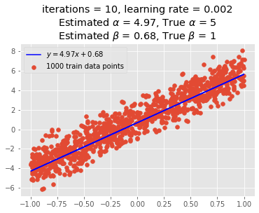

```python
z = w*train_data + b
plt.scatter(train_data, y, label="{} train data points".format(n))
plt.plot(train_data,z,'b-', label=r'$y={:.2f}x+{:.2f}$'.format(w,b))
plt.legend()
plt.title(r'iterations = {}, learning rate = {}'.format(iterations, eta)+ '\n' +
                                                     r'Estimated $\alpha$ = {:.2f}, True $\alpha$ = 5'.format(w) + '\n' +
                                                        r'Estimated $\beta$ = {:.2f}, True $\beta$ = 1'.format(b))

plt.show()
```

2. Repeat the previous question using Newton’s method

##### *Answer* ***(2)***

```python
from tqdm import tqdm

#initialize beta, alpha, and number of iterations
w, b = 0.5, 0.5
eta = 0.002
iterations = 1500

w_N = [w]
b_N = [b]

# Update w, b by calculating the gradient and making the update.
for _ in tqdm(range(iterations)):
  g = jnp.asarray(grad(make_mse(train_data, y), (0,1))(w,b)) #Gradient
  H = jnp.asarray(hessian(make_mse(train_data, y), (0,1))(w,b)) #Hessian Matrix
  H1 = jnp.linalg.inv(H) #Inverting the Hessian
  w_gradient, b_gradient = jnp.dot(H1,g) #H^(-1)*gradeint
  w, b = w - eta * w_gradient, b - eta * b_gradient
  w_N.append(w)
  b_N.append(b)
```

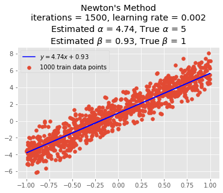

```python
z = w*train_data + b
plt.scatter(train_data, y, label="{} train data points".format(n))
plt.plot(train_data,z,'b-', label=r'$y={:.2f}x+{:.2f}$'.format(w,b))
plt.legend()
plt.title(r"Newton's Method" + '\n' +
    r'iterations = {}, learning rate = {}'.format(iterations, eta)+ '\n' +
                                                     r'Estimated $\alpha$ = {:.2f}, True $\alpha$ = 5'.format(w) + '\n' +
                                                        r'Estimated $\beta$ = {:.2f}, True $\beta$ = 1'.format(b))

plt.show()
```

3. The Fisher Information Matrix is defined as: $F = \mathbb{E}_{p(x\lvert \theta)}[\nabla_{\theta}\log p(x|\theta)\nabla_{\theta}\log p(x|\theta)^T]$ Prove that negative expected Hessian of log-likelihood is equal to the Fisher Information Matrix $F$

##### *Answer* ***(3)***

From properties of the log function: $\frac{d[log(x)]}{dx}=\frac{1}{x}$, and the fact that the Hessian matrix is the second derivatives matrix, we can write::

$$ \begin{align} \text{H}_{\log p(x \vert \theta)} &= \frac{d}{d\theta} \left( \frac{\nabla p(x \vert \theta)}{p(x \vert \theta)} \right) \\[5pt] &= \frac{ \text{H}_{p(x \vert \theta)} \, p(x \vert \theta) - \nabla p(x \vert \theta) \, \nabla p(x \vert \theta)^{\text{T}}}{p(x \vert \theta) \, p(x \vert \theta)} \\[5pt] &= \frac{\text{H}_{p(x \vert \theta)} \, p(x \vert \theta)}{p(x \vert \theta) \, p(x \vert \theta)} - \frac{\nabla p(x \vert \theta) \, \nabla p(x \vert \theta)^{\text{T}}}{p(x \vert \theta) \, p(x \vert \theta)} \\[5pt] &= \frac{\text{H}_{p(x \vert \theta)}}{p(x \vert \theta)} - \left( \frac{\nabla p(x \vert \theta)}{p(x \vert \theta)} \right) \left( \frac{\nabla p(x \vert \theta)}{p(x \vert \theta)}\right)^{\text{T}} \, \end{align} $$

Therefore, the negative expectation value is:

$$ \begin{align} \mathop{\mathbb{-E}}_{p(x \vert \theta)} \left[ \text{H}_{\log p(x \vert \theta)} \right] &=- \mathop{\mathbb{E}}_{p(x \vert \theta)} \left[ \frac{\text{H}_{p(x \vert \theta)}}{p(x \vert \theta)} - \left( \frac{\nabla p(x \vert \theta)}{p(x \vert \theta)} \right) \left( \frac{\nabla p(x \vert \theta)}{p(x \vert \theta)} \right)^{\text{T}} \right] \\[5pt] &=- \mathop{\mathbb{E}}_{p(x \vert \theta)} \left[ \frac{\text{H}_{p(x \vert \theta)}}{p(x \vert \theta)} \right] + \mathop{\mathbb{E}}_{p(x \vert \theta)} \left[ \left( \frac{\nabla p(x \vert \theta)}{p(x \vert \theta)} \right) \left( \frac{\nabla p(x \vert \theta)}{p(x \vert \theta)}\right)^{\text{T}} \right] \\[5pt] &=- \int \frac{\text{H}_{p(x \vert \theta)}}{p(x \vert \theta)} p(x \vert \theta) \, \text{d}x \, + \mathop{\mathbb{E}}_{p(x \vert \theta)} \left[ \nabla \log p(x \vert \theta) \, \nabla \log p(x \vert \theta)^{\text{T}} \right] \\[5pt] &= -\text{H}_{\int p(x \vert \theta) \, \text{d}x} \, + \text{F} \\[5pt] &= -\text{H}_{1} + \text{F} \\[5pt] &= \text{F} \, \end{align} $$

4. Prove that Fisher Information Matrix F is the Hessian of KL-divergence between two distributions $p ( x | θ )$ and $p ( x | θ ′ )$ with respect to $θ ′$ evaluated at $θ ′ = θ$

##### *Answer* ***(4)***

By the definitions of KL-divergence and the Hessian matrix:

$$ \begin{align} H_{KL}&=\nabla^{2}_{\theta '} \left[\int p(x|\theta)log\left(\frac{p(x|\theta)}{p(x|\theta ')} \right)dx \right] \\ &=\nabla^{2}_{\theta '}\left[\int p(x|\theta)log\left(p(x|\theta) \right)dx \right] - \nabla^{2}_{\theta '}\left[\int p(x|\theta)log\left(p(x|\theta ') \right)dx \right] \\ &= 0 - \int p(x \vert \theta) \, \nabla_{\theta'}^2 \log p(x \vert \theta') \, \text{d}x \\ &=\mathop{\mathbb{-E}}_{p(x \vert \theta)} \left[ \text{H}_{\log p(x \vert \theta')} \right] \end{align}$$

Which tells us that according to the derivation in the last section is equal to F.

##### *Answer* ***(5)***

```python
from tqdm import tqdm

def mse_val(params, xy):
  w, b = params
  x, y = xy
  return np.sum(jnp.power(x*w + b - y, 2))/2

def Fisher_1p(params, xy):
  g = grad(mse_val)(params, xy)
  return jnp.outer(g,g)

def Fisher(params,data):
  sum = vmap(Fisher_1p, in_axes=(None,0))(params, data)
  F = jnp.average(sum, axis=0)
  return F


#initialize beta, alpha, and number of iterations
params = jnp.array([0.5,0.5])
eta = 0.002
iterations = 100

w_F = [params[0]]
b_F = [params[1]]

# Update w, b by calculating the gradient and making the update.
for _ in tqdm(range(iterations)):
  g = jnp.asarray(grad(make_mse(train_data, y), (0,1))(params[0],params[1])) #Gradient
  F = Fisher(params, (train_data,y)) #Fisher Matrix
  F1 = jnp.linalg.inv(F) #Inverting Fisher Matrix
  w_gradient, b_gradient = jnp.dot(F1,g) #H^(-1)*gradeint
  w = params[0]
  b = params[1]
  w, b = w - eta * w_gradient, b - eta * b_gradient
  params = jnp.array([w,b])
  w_F.append(params[0])
  b_F.append(params[1])
```

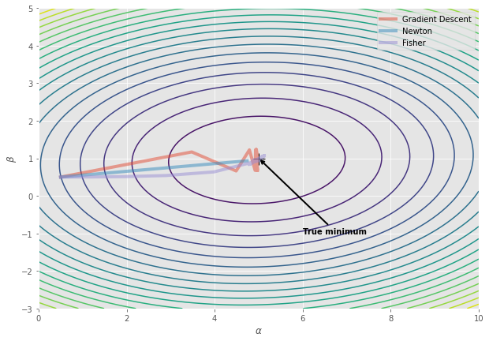

```python
X, Y = jnp.meshgrid(jnp.linspace(0,10,100), jnp.linspace(-3,5,100))
Z = vmap(vmap(lambda w, b : mse_val((w,b),(train_data,y))))(X,Y) #vmap onece for multiple w,b and vmap second for the meshgrid

plt.figure(figsize= (10,7))
plt.contour(X,Y,Z, levels = jnp.linspace(Z.min(),Z.max(),20))
#plt.colorbar()
plt.xlabel(r'$\alpha$')
plt.ylabel(r'$\beta$')
plt.plot(5,1,'k+', markersize=15)
plt.annotate('True minimum',(5,1),(6,-1), weight='bold',
                 # color=color,
                 arrowprops=dict(arrowstyle="->",
                 linewidth=2,
                 color = 'black',
                 connectionstyle='arc3'))
plt.plot(w_g,b_g, linewidth=4 , alpha=0.5 ,label='Gradient Descent')
plt.plot(w_N,b_N, linewidth=4 , alpha=0.5 ,label='Newton')
plt.plot(w_F,b_F, linewidth=4 , alpha=0.5 ,label='Fisher')
plt.legend()
```

## Bayesian Linear Regression with Nonlinear Basis Functions

Bayesian linear regression can be naturally extended to support approximation of nonlinear functions via the use of features or basis functions such as polynomials or trigonometric features. In fact, the case covered in class is just a special case of polynomial basis where you only use bias term and the identity mapping $ϕ ( x ) = x$ , $Φ ( x ) = [ 1 , x ]$ . It is straightforward to use other bases to do Bayesian linear regression. Here consider two sets of data both randomly sampled $N = 200$ observations within interval $x ∈ [ − 1 , 1 ]$.

$$ y_1(x) = \sin(\pi x) + \sin(3\pi x) + \sin(4\pi x) + \epsilon $$$$ y_2(x) = 1.5 - 2x - 3x^2 + 3x^3 + \epsilon $$

where $\epsilon$ corresponds to a zero mean uncorrelated Gaussian noise with variance set equal to 10 percent of your data’s standard deviation.

1. Generate these two data sets and visualize them

##### *Answer* ***(1)***

```
WARNING:absl:No GPU/TPU found, falling back to CPU. (Set TF_CPP_MIN_LOG_LEVEL=0 and rerun for more info.)
```

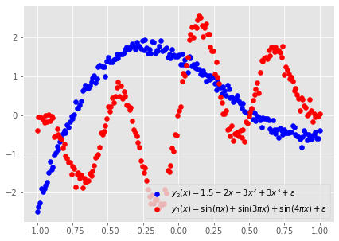

```python
key = random.PRNGKey(1)

# Generate data
x = np.linspace(-1,1,200)

y1 = np.sin(np.pi*x) + np.sin(3*np.pi*x) + np.sin(4*np.pi*x)
eps1 = np.random.normal(0, 0.1*np.std(y1), len(y1))
y1 = y1 + eps1

y2 = 1.5 -2*x - 3*x**2 + 3*x**3
eps2 = np.random.normal(0, 0.1*np.std(y2), len(y2))
y2 = y2 + eps2

# Plotting

plt.figure(figsize=(7,5))
plt.scatter(x,y2, color='blue', label=r'$y_2(x) = 1.5 - 2x - 3x^2 + 3x^3 + \epsilon$')
plt.scatter(x,y1, color='red', label=r'$y_1(x) = \sin(\pi x) + \sin(3\pi x) + \sin(4\pi x) + \epsilon$')
plt.legend()
```

2. Consider two Bayesian linear regression models with the following feature mappings:
- Identity basis: $Φ ( x ) = [ 1 , x ]$
- Fourier basis: $\Phi(x) = [0, 1, \sin(\pi x), \cos(\pi x), \sin(2\pi x), \cos(2\pi x), \dots, \sin(M\pi x), \cos(M\pi x)]$
- [Legendre basis](https://en.wikipedia.org/wiki/Legendre_polynomials)

Assuming the corresponding likelihood and priors:

$$ p(y\lvert x,w) = \mathcal{N}(y\mid w^{T}\phi(x),\alpha^{-1}I), \ p(w)=\mathcal{N}(w\mid 0,\beta^{-1}I), \ \alpha=5, \beta = 0.1 $$

derive the expression of the objective of your MLE and MAP estimations

##### *Answer* ***(2)***

We can use the same theory we saw in class, just with a design matrix instead of the input matrix $\pmb{X}$. In our case the design matrix $\pmb{\Phi}$ will be $\pmb{X} \rightarrow \pmb{\Phi}(x)$:

$$ \pmb{\Phi}(x) = \begin{pmatrix} \phi_{0}(x_1) & \phi_{1}(x_1) & \dots & \phi_{j-1}(x_1) \\ \phi_{0}(x_2) & \phi_{1}(x_2) \\ \vdots & \vdots & \ddots & \vdots \\ \phi_{0}(x_N) & \phi_{1}(x_N) & ... & \phi_{j-1}(x_N) \end{pmatrix} $$

And for the Legendre we will use the following Rodrigues' formula:

$$ \pmb{\phi}_j(x) = \frac{1}{2^j j!} \frac{d^j}{dx^j}(x^2-1)^j $$

3. Implement JAX code to do the regressions with these different basis. Train your model and show the results for both data set including the training data, the MLE prediction of the curve, the MAP prediction of the curve and 100 samples drawn from the predictive posterior distributions. You are free to choose the basis functions order and comments on your results

##### *Answer* ***(3)***

```python
class BayesianLinearRegression:
  """
    Linear regression model: y = (w.T)*x + \epsilon
    w ~ N(0,beta^(-1)I)
    P(y|x,w) ~ N(y|(w.T)*x, alpha^(-1)I)
  """
  def __init__(self, X, y, alpha = 1.0, beta = 1.0):
      # Store training data
      self.X = X
      self.y = y
      # Store precisions
      self.alpha = alpha
      self.beta = beta
      # Small jitter for numerically stable matrix inversion
      self.jitter = 1e-8

  # Computes the MLE estimate of the regression weights
  def fit_MLE(self):
      xTx_inv = np.linalg.inv(np.matmul(self.X.T,self.X) + self.jitter*np.eye(self.X.shape[1]))
      xTy = np.matmul(self.X.T, self.y)
      w_MLE = np.matmul(xTx_inv, xTy)
      self.w_MLE = w_MLE
      return w_MLE

  # Computes the MAP estimate of the regression weights
  def fit_MAP(self):
      Lambda = np.matmul(self.X.T,self.X) + \
               (self.beta/self.alpha)*np.eye(self.X.shape[1])
      Lambda_inv = np.linalg.inv(Lambda)
      xTy = np.matmul(self.X.T, self.y)
      mu = np.matmul(Lambda_inv, xTy)
      self.w_MAP = mu
      self.Lambda_inv = Lambda_inv
      return mu, Lambda_inv

  # Computes the predictive posterior distribution
  def predictive_distribution(self, X_star):
      mean_star = np.dot(X_star, self.w_MAP)
      var_star = np.matmul(X_star, np.matmul(self.Lambda_inv, X_star.T))

      return mean_star, var_star
```

```python
import scipy.special as sp

def P_data(x, order):
  X_P = np.zeros((len(x),order))
  for i in range(order):
    X_P[:,i] = sp.legendre(i)(x)
  return X_P

def F_data(x, order):
  X_F = np.zeros((len(x),order))
  for i in range(order):
      if i == 0:
       X_F[:,i] = 1
      if i % 2 != 0:
       X_F[:,i] = np.sin(np.pi*x*i)
      else:
       X_F[:,i] = np.cos(np.pi*x*i)
  return X_F

Y1 = y1[:, np.newaxis]
Y2 = y2[:, np.newaxis]

order = 5
x = np.linspace(-1,1,200)
x_star = np.linspace(-1,1,300)
X_F = F_data(x, order)
X_P = P_data(x, order)
X_F_star = F_data(x_star, order)
X_P_star = P_data(x_star, order)
```

```python
# Define model
alpha = 5
beta = 0.1

def model(x, y, X_star, alpha, beta):
  m = BayesianLinearRegression(x,y,alpha,beta)
  w_MLE = m.fit_MLE()
  w_MAP, Lambda_inv = m.fit_MAP()
  Y_MLE = np.dot(X_star,w_MLE)
  Y_MAP = np.dot(X_star,w_MAP)

  num_samples = 20
  mean_star, var_star = m.predictive_distribution(X_star)
  samples = random.multivariate_normal(key, mean_star.flatten(), var_star, (num_samples,), method='svd')
  percentiles = np.percentile(samples, [5.0, 95.0], axis=0)

  return Y_MLE, Y_MAP, percentiles

Y1_F_MLE, Y1_F_MAP, Y1_F_per = model(X_F, Y1, X_F_star, alpha, beta)
Y2_F_MLE, Y2_F_MAP, Y2_F_per = model(X_F, Y2, X_F_star, alpha, beta)
Y1_P_MLE, Y1_P_MAP, Y1_P_per = model(X_P, Y1, X_P_star, alpha, beta)
Y2_P_MLE, Y2_P_MAP, Y2_P_per = model(X_P, Y2, X_P_star, alpha, beta)
```

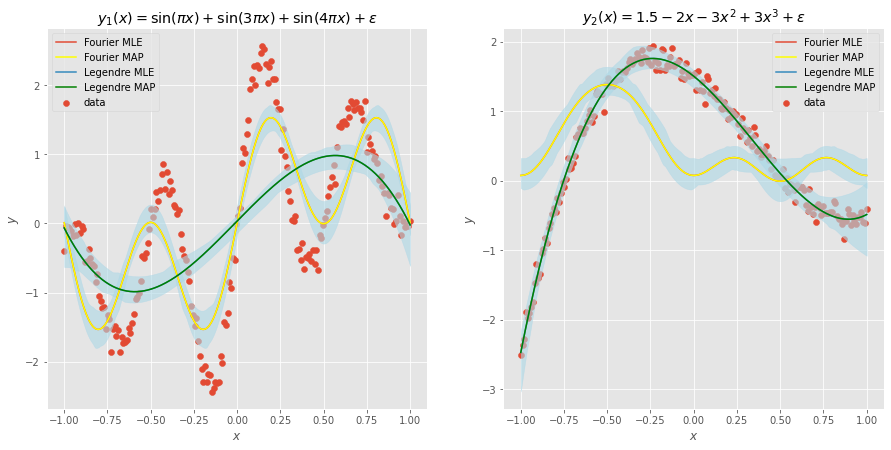

```python
fig, (ax1, ax2) = plt.subplots(1, 2, figsize=(15,7))
ax1.scatter(x, y1, label='data')
ax1.plot(x_star, Y1_F_MLE, label='Fourier MLE')
ax1.plot(x_star, Y1_F_MAP, label='Fourier MAP', color='yellow')
ax1.plot(x_star, Y1_P_MLE, label='Legendre MLE')
ax1.plot(x_star, Y1_P_MAP, label='Legendre MAP', color='green')
ax1.fill_between(x_star.flatten(), Y1_F_per[0, :], Y1_F_per[1, :], color='lightblue', alpha=0.6)
ax1.fill_between(x_star.flatten(), Y1_P_per[0, :], Y1_P_per[1, :], color='lightblue', alpha=0.6)
ax1.set_title(r'$y_1(x) = \sin(\pi x) + \sin(3\pi x) + \sin(4\pi x) + \epsilon$')
ax1.set_xlabel(r'$x$')
ax1.set_ylabel(r'$y$')
ax1.legend()

ax2.scatter(x, y2, label='data')
ax2.plot(x_star, Y2_F_MLE, label='Fourier MLE')
ax2.plot(x_star, Y2_F_MAP, label='Fourier MAP', color='yellow')
ax2.plot(x_star, Y2_P_MLE, label='Legendre MLE')
ax2.plot(x_star, Y2_P_MAP, label='Legendre MAP', color='green')
ax2.fill_between(x_star.flatten(), Y2_F_per[0, :], Y2_F_per[1, :], color='lightblue', alpha=0.6)
ax2.fill_between(x_star.flatten(), Y2_P_per[0, :], Y2_P_per[1, :], color='lightblue', alpha=0.6)
ax2.set_title(r'$y_2(x) = 1.5 - 2x - 3x^2 + 3x^3 + \epsilon$')
ax2.set_xlabel(r'$x$')
ax2.set_ylabel(r'$y$')
ax2.legend()
```

## MNIST Classification

Download the [MNIST data-set](http://yann.lecun.com/exdb/mnist/) of hand written digits

1. Parse the data and keep the $1,000$ images and their associated labels for each of the following digits: $0, 1, 2$. Further, randomly permute the data, and for each digit split the dataset to select $80$ percent of the data for training and $20$ percent for testing. Each image should have $28 × 28$ pixels

##### *Answer* ***(1)***

```python
# Upload the train dataset
# -- Upload the files train-images-idx3-ubyte.gz & train-labels-idx1-ubyte.gz
from google.colab import files
files.upload()
```

```
Saving train-images-idx3-ubyte.gz to train-images-idx3-ubyte.gz
Saving train-labels-idx1-ubyte.gz to train-labels-idx1-ubyte.gz
```

```python
# Open the gzip file and reading images into data
import gzip
f=gzip.open("/content/train-images-idx3-ubyte.gz",'r')

n = 50000

image_size = 28
num_images = n

f.read(16)
buf = f.read(image_size * image_size * num_images)
data = np.frombuffer(buf, dtype=np.uint8).astype(np.float32)
data = data.reshape(num_images, image_size, image_size, 1)

# Opening labels gzip file and reading into labels
f = gzip.open('/content/train-labels-idx1-ubyte.gz','r')
f.read(8)
labels = np.empty(n)
for i in range(n):
    buf = f.read(1)
    label = np.frombuffer(buf, dtype=np.uint8).astype(np.int64)
    labels[i] = label

# Extract digits
def remove(digit, x, y):
    idx = (y == digit).nonzero()
    return x[idx], y[idx]

data_0, label_0 = remove(0, data, labels)
data_1, label_1 = remove(1, data, labels)
data_2, label_2 = remove(2, data, labels)


def parse(data, label, percent):
  i = int(len(label)*percent)
  train = data[:i,:,:,:]
  test = data[i:,:,:,:]
  train_l = label[:i]
  test_l = label[i:]
  return train, test, train_l, test_l

# Permute the data
def shuffle(a, b):
    assert len(a) == len(b)
    p = np.random.permutation(len(a))
    return a[p], b[p]

tr_0, te_0, ltr_0, lte_0 = parse(data_0, label_0, 0.2)
tr_1, te_1, ltr_1, lte_1 = parse(data_1, label_1, 0.2)
tr_2, te_2, ltr_2, lte_2 = parse(data_2, label_2, 0.2)

train_d_01 = np.append(tr_0,tr_1, axis=0)
train_l_01 = np.append(ltr_0,ltr_1, axis=0)
test_d_01 = np.append(te_0,te_1, axis=0)
test_l_01 = np.append(lte_0,lte_1, axis=0)

train_d_012 = np.append(train_d_01,tr_2, axis=0)
train_l_012 = np.append(train_l_01,ltr_2, axis=0)
tr_012, ltr_012 = shuffle(train_d_012, train_l_012)





# this is the final training set and labels
tr_01, ltr_01 = shuffle(train_d_01, train_l_01)
te_01, lte_01 = shuffle(test_d_01, test_l_01)
```

2. Implement a logistic regression model and train it using gradient descent only on digit $0$ and digit $1$. The loss function that you should use is the binary cross entropy loss. Report the accuracy of your model on the test data and provide a visualization of the resulting confusion matrix

##### *Answer* ***(2)***

```python
from tqdm import tqdm

# Flattening to make the data ready
key = random.PRNGKey(1)
tr_01 = tr_01.squeeze()
X = tr_01.reshape(len(tr_01),28*28)
Y = ltr_01

W = random.normal(key, (28*28,))
b = random.normal(key, ())


def sigmoid(x):
    return 0.5 * (jnp.tanh(x / 2) + 1)

def a(W, b, inputs):
    return sigmoid(jnp.dot(inputs, W) + b)

@jit
def loss(W,b, targets, data):
    Z = jnp.dot(data, W) + b
    sig = 0.5 * (jnp.tanh(Z / 2) + 1)
    epsilon = 1e-5
    label_prob = sig * targets + (1 - sig) * (1 - targets)
    return -jnp.sum(jnp.log(label_prob + epsilon))


# Gradient descent
# Learning Rate
eta = 0.05
iterations = 1000

grad_loss = grad(loss, argnums=(0,1))

loss_history = []

X = random.normal(key, (len(tr_01),28*28))

for i in tqdm(range(iterations)):
    w_gradient, b_gradient = grad_loss(W,b, Y, X)
    W, b = W - eta * w_gradient, b - eta * b_gradient
    #print(loss(W, b, Y, X))
    loss_history.append(loss(W, b, Y, X))
```

```
WARNING:absl:No GPU/TPU found, falling back to CPU. (Set TF_CPP_MIN_LOG_LEVEL=0 and rerun for more info.)
```

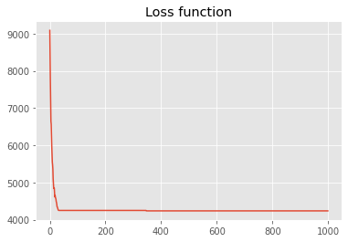

```python
plt.plot(loss_history)
plt.title('Loss function')
```

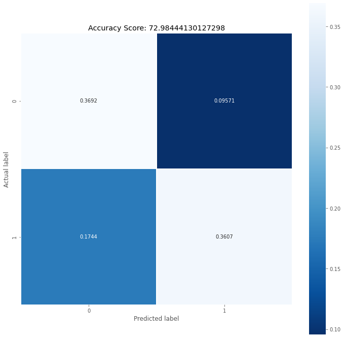

```python
from sklearn.metrics import confusion_matrix
import seaborn as sns

Z = jnp.dot(X, W) + b
acc = 0.5 * (jnp.tanh(Z / 2) + 1)
Y = Y.astype(int)
acc = acc.astype(int)
score2 = (sum(Y == acc) / len(Y) )* 100

cm = confusion_matrix(Y, acc, normalize='all')
#cm_normalized = cm.astype('float') / cm.sum(axis=1)[:, np.newaxis]

plt.figure(figsize=(12,12))
sns.heatmap(cm, annot=True,
            linewidths=.5, square = True, cmap = 'Blues_r', fmt='0.4g');

plt.ylabel('Actual label')
plt.xlabel('Predicted label')
all_sample_title = 'Accuracy Score: {0}'.format(score2)
plt.title(all_sample_title);
```

3. Perform logistic regression on all three digits (i.e. $0,1,2$). In this case you need to use a one-hot encoding of the output labels and the multi-class cross entropy loss. Report the accuracy of your model on the test data and provide a visualization of the resulting confusion matrix

##### *Answer* ***(3)***

```python
# Preparing the data with digits 0-1-2
train_d_012 = np.append(train_d_01,tr_2, axis=0)
train_l_012 = np.append(train_l_01,ltr_2, axis=0)
tr_012, ltr_012 = shuffle(train_d_012, train_l_012)

tr_012 = tr_012.squeeze()
X = tr_012.reshape(len(tr_012),28*28)
X = np.append(np.ones((len(X),1)), X, axis=1) # Add column of 1's
Y = ltr_012

# One-hot encoding for the labels
# 0-0-1 : digit 0
# 0-1-0 : digit 1
# 1-0-0 : digit 2

one_hot = np.zeros((len(X), 3))

for i in range(len(one_hot)):
  if Y[i] == 0:
    one_hot[i] = [0,0,1]
  if Y[i] == 1:
    one_hot[i] = [0,1,0]
  if Y[i] == 2:
    one_hot[i] = [1,0,0]

# W matrix with dimension (pixels x one_hot labels)
W = random.normal(key, (28*28+1,3))
```

```python
def softmax(A):
    expA = jnp.exp(A - jnp.max(A))
    return expA / expA.sum()

def loss_1(W,X,Y):
  epsilon = 1e-5
  p = softmax(jnp.dot(X,W))
  logp = jnp.log(p + epsilon)
  loss = -jnp.sum(jnp.dot(Y,p))
  return loss

v_loss_1 = vmap(loss_1, in_axes=(None,0,0))

def loss(W,X,Y):
  return -jnp.sum(v_loss_1(W,X,Y))
```

```python
itr = 100
eta = 0.001

grad_loss = grad(loss)

loss_history2 = []

for i in tqdm(range(itr)):
    g = grad_loss(W,X,one_hot)
    W = tree_multimap(lambda x, g: x - eta*g, W, g)
    loss_history2.append(loss(W, X, one_hot))
```

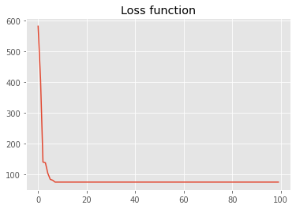

```python
plt.plot(loss_history2)
plt.title('Loss function')
```

```python
def pred(X,W):
  p = np.empty(len(X))
  for i in tqdm(range(len(p))):
    z = softmax(np.dot(X[i,:],W))
    if np.argmax(z) == 0:
      p[i] = 2
    if np.argmax(z) == 1:
      p[i] = 1
    if np.argmax(z) == 2:
      p[i] = 0
  return p

predict = pred(X,W)
```

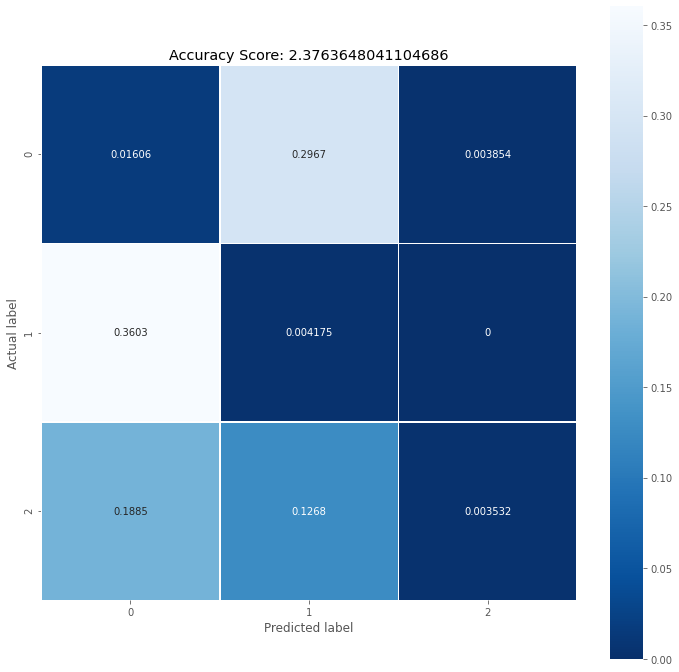

```python
Y = Y.astype(int)
predict = predict.astype(int)
score2 = (sum(Y == predict) / len(Y) )* 100

cm = confusion_matrix(Y, predict, normalize='all')
#cm_normalized = cm.astype('float') / cm.sum(axis=1)[:, np.newaxis]

plt.figure(figsize=(12,12))
sns.heatmap(cm, annot=True,
            linewidths=.5, square = True, cmap = 'Blues_r', fmt='0.4g');

plt.ylabel('Actual label')
plt.xlabel('Predicted label')
all_sample_title = 'Accuracy Score: {0}'.format(score2)
plt.title(all_sample_title);
```